# Statistical Inference Course Project

Antti Herala

In this report, the course about statistical inference is summarized in two parts. First, there is a simulation exercise, where the exponential distribution is simulated and compared to the theoretical values. In the second part, some basic hypothesis testing is done using the dataset ToothGrowth.

## Part 1: Simulation Exercise

Before the simulation, the constants are set, as well as the seed for replicability. Seed is set to 0, and three constant are set lambda for exponential distribution to 0.2, number of simulations to 1000, and sample size n to 40.

```r
set.seed(0)

lambda <- 0.2
nosim <- 1000
n <- 40
```

For data generation, an additional helper-function was done called generate(). It is used to generate enough data for the simulation.

```r
generate <- function(iter, avgs, lambda) {
    mns = NULL
    for(i in 1:iter) {mns = c(mns, mean(rexp(avgs, lambda)))}
    mns
}
```

To get some idea about the generated data, the means are calculated. Theoretical mean was given beforehand, and the sample mean is calculated with the mean()-function.

```r
data <- generate(nosim, n, lambda)

mu <- 1/lambda
X <- mean(data)

print(mu); print(X)
```

```
## [1] 5
```

```
## [1] 4.989678
```

As it can be seen, the sample mean is relatively close to the theoretical mean. A histogram is used to further show the difference, and also in order to illustrate the data.

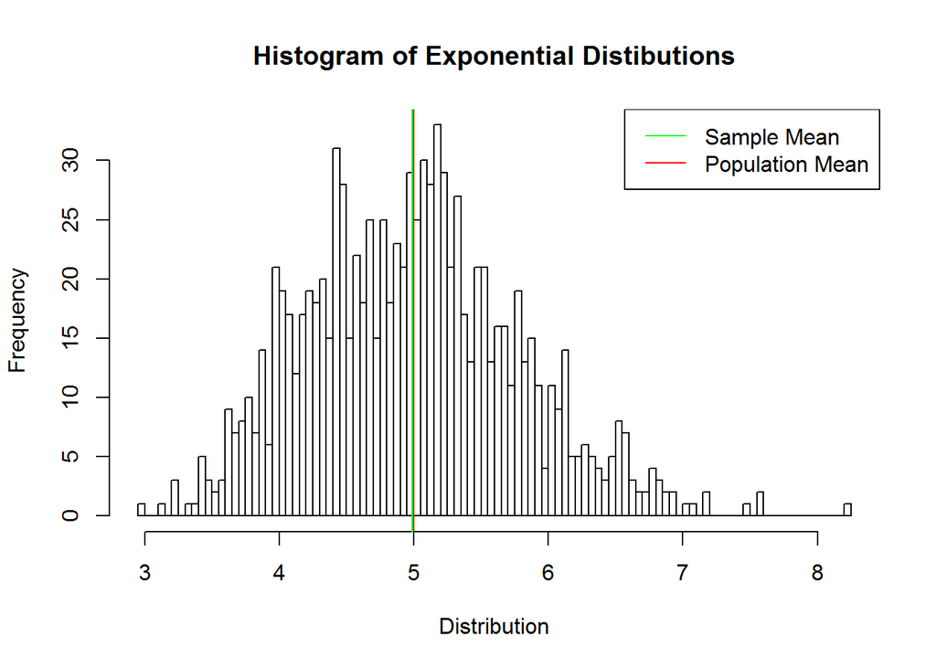

```r
hist(data,
    breaks=75,
    main= "Histogram of Exponential Distibutions",
    xlab = "Distribution"
)
abline(v=X, col="green")
abline(v=mu, col="red")
legend("topright",
    c("Sample Mean", "Population Mean"),
    lty=c(1,1),
    col = c("green", "red")
)
```

Next, the variances are compared. The theoretical variance is calculated using the standard deviation, that is 1/lambda (equal to the mean) for exponential distribution. The variance of the simulated data was estimated using the var()-function available in R.

```r
sigma <- 1/lambda
var_pop <- sigma^2/n #theoretical variance

var_s <- var(data) #sample variance

print(var_pop); print(var_s)
```

```
## [1] 0.625
```

```
## [1] 0.6181582
```

Even the variance of the sample is somewhat close to the theoretical value. Because the sample data so closely resembles the population and because of the shape of the histogram, it is possible to question, if this distribution could be close to a normal distribution.

To highlight the relation to normal distribution, another histogram is drawn, and a normally distributed curve with mean of 1/lambda and sd of 1/lambda/sqrt(n) is added. The sample curve is compared to this theoretical curve.

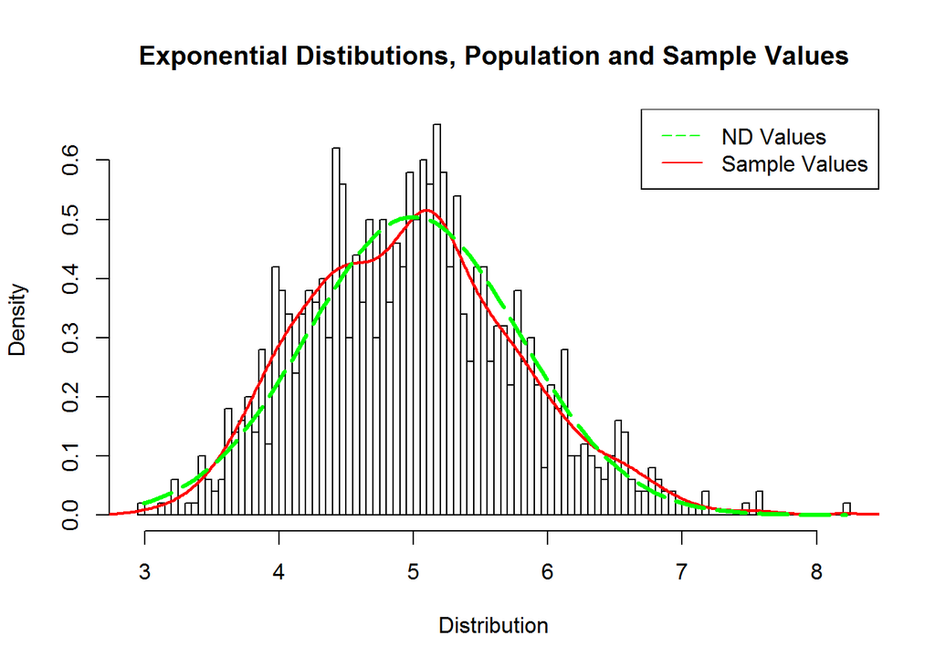

```r
hist(data,
    breaks=75,
    prob=TRUE,
    main="Exponential Distibutions, Population and Sample Values",
    xlab="Distribution"
)
lines(density(data), lwd=2, col="red")
xfit <- seq(min(data), max(data), length = 100)
yfit <- dnorm(xfit, mean = 1/lambda, sd = (1/lambda/sqrt(n)))
lines(xfit, yfit, lwd=3, col="green", lty=5)
legend("topright",
    c("ND Values", "Sample Values"),
    lty=c(5,1),
    col = c("green", "red")
)
```

The sample curve is already a good approximation of a normal distribution curve, when there are 1000 simulations. If the sample distribution is normal distributed, increasing the number of simulations should push the sample curve even closer to the normal distribution curve. The sample size is increased from 1000 to 100000 and the same histogram is drawn. If the distribution is normal, the sample curve and the normal distribution curve should be even even closer to each other than in the previous histogram.

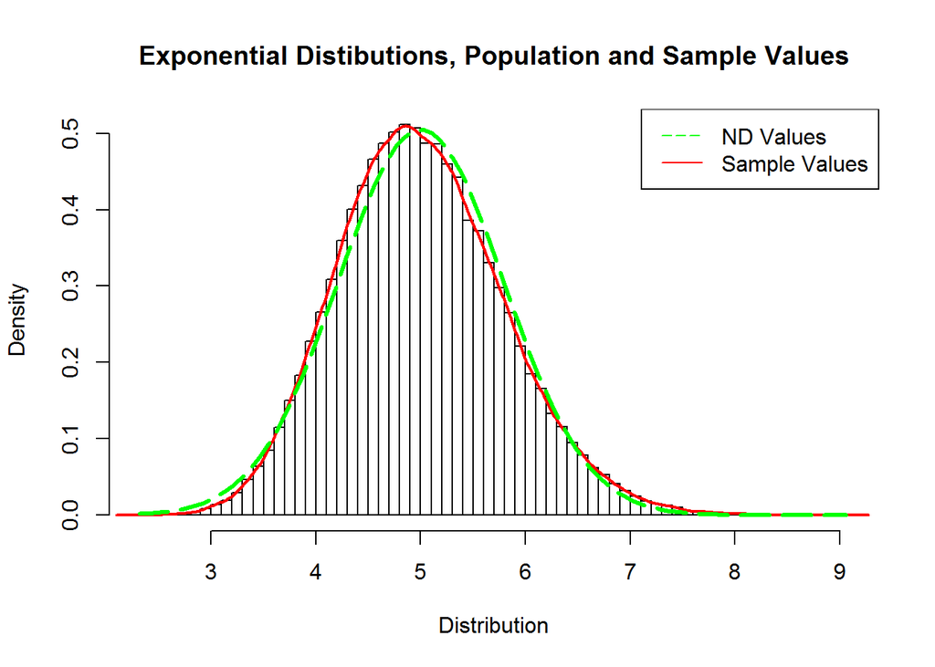

```r
data <- generate(100000, n, lambda)

hist(data,
    breaks=75,
    prob=TRUE,
    main="Exponential Distibutions, Population and Sample Values",
    xlab="Distribution"
)
lines(density(data), lwd=2, col="red")
xfit <- seq(min(data), max(data), length = 100)
yfit <- dnorm(xfit, mean = 1/lambda, sd = (1/lambda/sqrt(n)))
lines(xfit, yfit, lwd=3, col="green", lty=5)
legend("topright",
    c("ND Values", "Sample Values"),
    lty=c(5,1),
    col = c("green", "red")
)
```

These attributes of the samples would suggest, that the distribution is approximately normal and the distribution follows the CLT.

## Part 2: Basic Inferential Data Analysis

For the second part of this assignment, some hypothesis testing is done with the ToothGrowth-dataset from R.

```r
data("ToothGrowth")
str(ToothGrowth)
```

```
## 'data.frame':    60 obs. of  3 variables:
##  $ len : num  4.2 11.5 7.3 5.8 6.4 10 11.2 11.2 5.2 7 ...
##  $ supp: Factor w/ 2 levels "OJ","VC": 2 2 2 2 2 2 2 2 2 2 ...
##  $ dose: num  0.5 0.5 0.5 0.5 0.5 0.5 0.5 0.5 0.5 0.5 ...
```

```r
summary(ToothGrowth)
```

```
##       len        supp         dose
##  Min.   : 4.20   OJ:30   Min.   :0.500
##  1st Qu.:13.07   VC:30   1st Qu.:0.500
##  Median :19.25           Median :1.000
##  Mean   :18.81           Mean   :1.167
##  3rd Qu.:25.27           3rd Qu.:2.000
##  Max.   :33.90           Max.   :2.000
```

As can be seen, the str()-function shows that the dataset has three columns: len, supp, and dose. From the documentation (URL: https://stat.ethz.ch/R-manual/R-devel/library/datasets/html/ToothGrowth.html) len means Tooth length, supp means Supplement type or delivery method, and dose is the Dose in milligrams of vitamin C per day.

The summary shows, that the tooth length varies between around 4 and 34, with a mean and median around 19. There are two types of delivery methods, orange juice (OJ) and Ascorbic acid (VC) and both have the length of 30. The dose has three levels despite being a numeric: 0.5, 1, and 2 milligrams per day, evident from summary but also can be seen from the documentation.

To get some idea, what should be hypothized from the data, a boxplot is drawn.

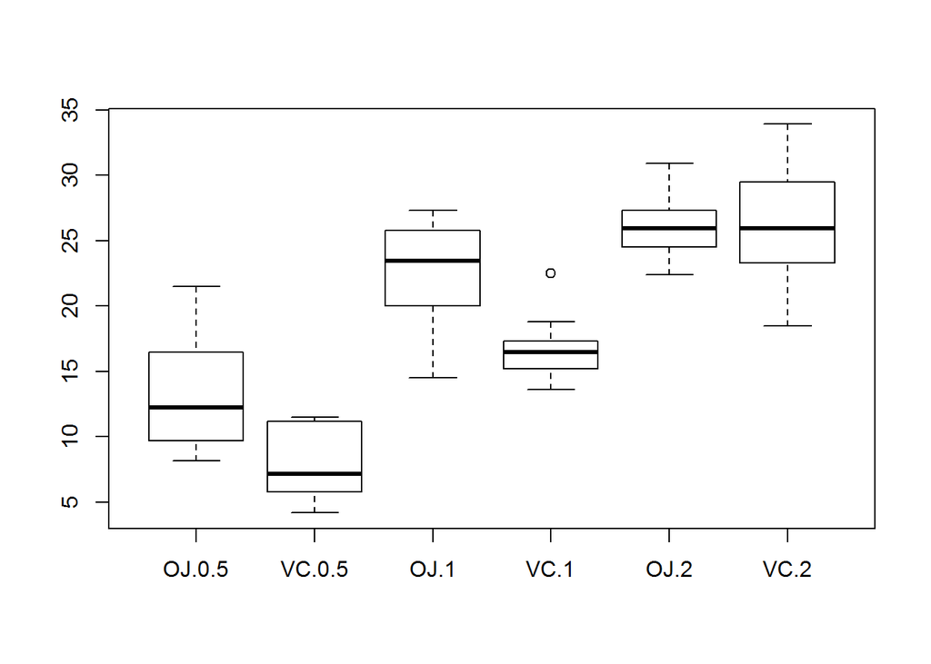

```r
boxplot(len ~ supp*dose, data=ToothGrowth)
```

This boxplot offers two distinguished features: there seems to be differences in tooth length based on the dose, but also based on teh supplement type. These aspects need to be further looked at.

First, the issue of supplement type affecting tooth length. The rejection region is set to .95/the p-value at .05.

H0 = Tooth length and supplement type do not correlate

Ha = Tooth lenght and supplement type correlate

First the t-test for supp affecting len…

```r
t.test(len~supp, data=ToothGrowth)
```

```
##
##  Welch Two Sample t-test
##
## data:  len by supp
## t = 1.9153, df = 55.309, p-value = 0.06063
## alternative hypothesis: true difference in means is not equal to 0
## 95 percent confidence interval:
##  -0.1710156  7.5710156
## sample estimates:
## mean in group OJ mean in group VC
##         20.66333         16.96333
```

…shows that 0 is within the confidence interval and the p-value (0.06) is larger than the .05 that was set. This test would suggest, that the null hypothesis is accepted, and the delivery method does not correlate with tooth length.

Next, the correlation between the tooth growth and the dose of vitamin C is calculated. First, it is necessary to do some transformation to the data in order to allow more suitable structure for the tests. First the data is subsetted based on their dosages, and afterwards further subsetted by the supplement type.

```r
dose_low <- subset(ToothGrowth, ToothGrowth$dose == 0.5)
dose_mid <- subset(ToothGrowth, ToothGrowth$dose == 1)
dose_high <- subset(ToothGrowth, ToothGrowth$dose == 2)

dose_low_oj <- subset(dose_low, dose_low$supp == "OJ")
dose_low_vc <- subset(dose_low, dose_low$supp == "VC")

dose_mid_oj <- subset(dose_mid, dose_mid$supp == "OJ")
dose_mid_vc <- subset(dose_mid, dose_mid$supp == "VC")

dose_high_oj <- subset(dose_high, dose_high$supp == "OJ")
dose_high_vc <- subset(dose_high, dose_high$supp == "VC")
```

To test, whether or not the tooth growth correlates with the dose, it is necessary to hypothesize, if the dose of vitamin C affects tooth growth. This can be done with the smallest dosage, since if the smallest dose correlates, larger doses correlate as well. Again, p-value is set at .05.

H0 = Tooth length and giving vitamin C do not correlate

Ha = Tooth length and giving vitamin C correlate

```r
t.test(dose_low$len, dose_low$dose)
```

```
##
##  Welch Two Sample t-test
##
## data:  dose_low$len and dose_low$dose
## t = 10.043, df = 19, p-value = 4.912e-09
## alternative hypothesis: true difference in means is not equal to 0
## 95 percent confidence interval:
##   7.999046 12.210954
## sample estimates:
## mean of x mean of y
##    10.605     0.500
```

As can be seen, the p-value is significantly lower than .05, and the confidence interval is always positive and does not contain 0. This would suggest, that H0 has to be rejected, giving that vitamin C affects the tooth growth.

As for the final part, it is necessary to calculate, whether or not the amount of vitamin C is affected by the supplement type. In other words, does one supplement type allow better tooth grow with a specific dose. p-value is set to .05.

H0 = Supplement type does not correlate with dosage (0.5 mg/day)

Ha = Supplement type correlates with dosage (0.5 mg/day)

```r
t.test(dose_low_oj$len, dose_low_vc$len)
```

```
##
##  Welch Two Sample t-test
##
## data:  dose_low_oj$len and dose_low_vc$len
## t = 3.1697, df = 14.969, p-value = 0.006359
## alternative hypothesis: true difference in means is not equal to 0
## 95 percent confidence interval:
##  1.719057 8.780943
## sample estimates:
## mean of x mean of y
##     13.23      7.98
```

With the 95% confidence interval, the p-value is significantly lower than .05, which would suggest that H0 has to be rejected and the supplement type affects tooth growth, when dosage is 0.5 mg/day.

When the dose is 1 mg/day, the hypotheses are:

H0 = Supplement type does not correlate with dosage (1 mg/day)

Ha = Supplement type correlates with dosage (1 mg/day)

```r
t.test(dose_mid_oj$len, dose_mid_vc$len)
```

```
##
##  Welch Two Sample t-test
##
## data:  dose_mid_oj$len and dose_mid_vc$len
## t = 4.0328, df = 15.358, p-value = 0.001038
## alternative hypothesis: true difference in means is not equal to 0
## 95 percent confidence interval:
##  2.802148 9.057852
## sample estimates:
## mean of x mean of y
##     22.70     16.77
```

Again, the t-test yields a significantly small p-value than was set, which suggests that H0 has to be rejected and the supplement type affects tooth growth when the dose of vitamin C is 1 mg/day.

Finally, for the large dose (2mg/day), the hypotheses are:

H0 = Supplement type does not correlate with dosage (2 mg/day)

Ha = Supplement type correlates with dosage (2 mg/day)

```r
t.test(dose_high_oj$len, dose_high_vc$len)
```

```
##
##  Welch Two Sample t-test
##
## data:  dose_high_oj$len and dose_high_vc$len
## t = -0.046136, df = 14.04, p-value = 0.9639
## alternative hypothesis: true difference in means is not equal to 0
## 95 percent confidence interval:
##  -3.79807  3.63807
## sample estimates:
## mean of x mean of y
##     26.06     26.14
```

Here, the p-value is significantly higher than .05, actually going closer to 1. This means that H0 can be accepted and the supplement type does not affect tooth growth, when the dosage is 2 mg/day.

To conclude, the results in this sample would suggest, that the supplement type does not affect tooth growth by itself, while giving vitamin C does. It was also noticed, that the supplement type affects tooth growth, when the dose of vitamin C is less or equal to 1 mg per day, but with larger dosage (2 mg/day in this sample) it does not have an effect.